# Apply scLASER on IBD

Lauren Vanderlinden

Report generated: January 05, 2026

# Overview

Look at Thomas et al 2024 and analyze their longitudinal dataset with our pipeline.

```r
rm(list=ls())
library(Matrix, lib.loc = "/projects/lvanderlinden@xsede.org/Rstudio_libs/4.2.2/")
library(scLASER)
```

```r
library(kableExtra)
library(ggplot2)
library(dplyr)
library(DT)
library(table1)
source(file="/projects/lvanderlinden@xsede.org/pvalForTable1_updatedForNA.R")
```

# Read in Raw Data

This data was downloaded from: https://zenodo.org/records/14007626 and saved under the IBD_Thomas2024 folder.

```r
data.loc <- "/pl/active/fanzhanglab/lvanderlinden/publicDatasets/IBD_Thomas2024"

features <- list.files(data.loc, recursive="FALSE")
IBD.filenames <- paste0(data.loc, "/", features)

paired_samples <- read.delim(file=paste0(data.loc, "/paired_sample_list.csv"))
dim(paired_samples)

##### Load in fibroblast/pericyte cells ##########
library(zellkonverter)

# read in the h5ad files (fibroblast/pericyte cells have the "fib" in name)
sce <- readH5AD(IBD.filenames[grep("fib", IBD.filenames)])
saveRDS(sce, file="/pl/active/fanzhanglab/lvanderlinden/publicDatasets/IBD_Thomas2024/data/fibroblast.asSCEobj.rds")


meta <- colData(sce)
meta.uniqueSamples <- meta[!duplicated(meta$sample_id),]
nVisits <- as.data.frame(table(meta.uniqueSamples$Patient))
patientCD5 <- meta.uniqueSamples[which(meta.uniqueSamples$Patient=="CD5"),]

exp <- assay(sce, "X")
assayNames(sce)
reducedDimNames(sce)
sapply(reducedDims(sce), dim)  # rows = cells, cols = components
head(reducedDim(sce, reducedDimNames(sce)[1]))

harmony_pcs <- reducedDims(sce)$X_harmony
umap <- reducedDims(sce)$X_umap
colnames(umap) <- c("UMAP1", "UMAP2")
save(umap, harmony_pcs, meta, file="/pl/active/fanzhanglab/lvanderlinden/publicDatasets/IBD_Thomas2024/data/fibroblast_harmonyPCs_meta.Rdata")
```

What does the meta data look like? Let’s check out the first 6 rows.

```r
datatable(head(as.data.frame(meta)))
```

|  | sample_id | Patient | Disease | Site | Treatment | Disease_duration | Inflammation | Age | Gender | Ethnicity | Inflammation_score | Ileum_vs_Colon | LibraryType | CellsLoaded | Match | Batch | doublet_scores | predicted_doublets | n_genes_by_counts | total_counts | total_counts_mt | pct_counts_mt | total_counts_rp | pct_counts_rp | total_counts_hb | pct_counts_hb | total_counts_ig | pct_counts_ig | S_score | … |
| --- | --- | --- | --- | --- | --- | --- | --- | --- | --- | --- | --- | --- | --- | --- | --- | --- | --- | --- | --- | --- | --- | --- | --- | --- | --- | --- | --- | --- | --- | --- |
| AAACGCTGTAGCGCTC-1-CID003352-2 | CID003352-2 | UC1 | UC | Rectum | Post | 29 | Inflamed | 26 | M | Caucasian | 7.98423196 | Rectum | 3 prime V3 | 10000 | Yes | Batch_1 | 0.041747572815534 | False | 705 | 1283 | 298 | 23.2268123626709 | 103 | 8.0280590057373 | 0 | 0 | 0 | 0 | -0.0305594075471163 | … |
| AAAGGTAAGCTACTGT-1-CID003352-2 | CID003352-2 | UC1 | UC | Rectum | Post | 29 | Inflamed | 26 | M | Caucasian | 7.98423196 | Rectum | 3 prime V3 | 10000 | Yes | Batch_1 | 0.0577830188679245 | False | 5595 | 26629 | 1613 | 6.05730581283569 | 3038 | 11.4086141586304 | 0 | 0 | 0 | 0 | -1.26176607608795 | … |
| AAAGGTAAGGACAACC-1-CID003352-2 | CID003352-2 | UC1 | UC | Rectum | Post | 29 | Inflamed | 26 | M | Caucasian | 7.98423196 | Rectum | 3 prime V3 | 10000 | Yes | Batch_1 | 0.0775490665390139 | False | 5065 | 18370 | 2094 | 11.3990201950073 | 2137 | 11.6330976486206 | 0 | 0 | 1 | 0.00544365821406245 | -0.742071151733398 | … |
| AAAGGTATCATCCTAT-1-CID003352-2 | CID003352-2 | UC1 | UC | Rectum | Post | 29 | Inflamed | 26 | M | Caucasian | 7.98423196 | Rectum | 3 prime V3 | 10000 | Yes | Batch_1 | 0.0629283489096573 | False | 1926 | 4755 | 672 | 14.1324920654297 | 316 | 6.64563608169556 | 0 | 0 | 0 | 0 | -0.129079982638359 | … |
| AAAGTGACAGGTGTTT-1-CID003352-2 | CID003352-2 | UC1 | UC | Rectum | Post | 29 | Inflamed | 26 | M | Caucasian | 7.98423196 | Rectum | 3 prime V3 | 10000 | Yes | Batch_1 | 0.100869565217391 | False | 2845 | 8309 | 775 | 9.32723617553711 | 927 | 11.1565771102905 | 0 | 0 | 0 | 0 | -0.360564053058624 | … |
| AAATGGACAAGTGGTG-1-CID003352-2 | CID003352-2 | UC1 | UC | Rectum | Post | 29 | Inflamed | 26 | M | Caucasian | 7.98423196 | Rectum | 3 prime V3 | 10000 | Yes | Batch_1 | 0.041747572815534 | False | 2092 | 7018 | 403 | 5.74237680435181 | 1426 | 20.3191795349121 | 0 | 0 | 2 | 0.0284981485456228 | -0.381414711475372 | … |

## Create an scLASER object

```r
#make the disease/healthy variable as binary
meta$disease_healthy0_other1 <- ifelse(meta$Disease=="Healthy", 0, 1)

# from the data we read in, make an scLASER object with their metadata, umap and the harmony PCs they calculated.
obj <- scLASER::scLASER(metadata=as.data.frame(meta), umap=as.data.frame(umap), harmony = as.matrix(harmony_pcs))
```

# Create NAM PCs

For this report, make a neighborhood abundence matrix (NAM) and reduce down by PCA and take top 30 PCs moving forward.

```r
# make NAM and get the top 30 NAM PCs
obj = scLASER::association_nam_LV(obj = obj,
                          test_var = "disease_healthy0_other1",
                          #test_var="Remission_status",
                          samplem_key = "sample_id",
                          graph_use = "RNA_nn",
                          batches = "Batch",
                          covs = c("Age", "Gender"),
                          nsteps = NULL,
                          verbose=TRUE,
                          assay=NULL,
                          key="NAMPC_",
                          maxnsteps=15L,
                          max_frac_pcs=0.15, # added option to pass number of PCs, for potential speedups
                          n_pcs = 30,
                          ks=NULL,
                          Nnull=1000,
                          force_permute_all=FALSE,
                          local_test=TRUE,
                          seed=1234,
                          return_nam=TRUE
)

# This step takes some time depending on how large your dataset.  Would reccommend saving after this point.
saveRDS(obj, file="/pl/active/fanzhanglab/lvanderlinden/publicDatasets/IBD_Thomas2024/data/fibroblast.scLASERobj.rds")
```

Let’s look at what the NAM PC matrix looks like. These will be our outcomes in the subsequent linear mixed effect models.

```r
datatable(as.data.frame(head(obj@nam_pcs)), rownames = FALSE)
```

| PC1 | PC2 | PC3 | PC4 | PC5 | PC6 | PC7 | PC8 | PC9 | PC10 | PC11 | PC12 | PC13 | PC14 | PC15 | PC16 | PC17 | PC18 | PC19 | PC20 | PC21 | PC22 | PC23 | PC24 | PC25 | PC26 | PC27 | PC28 | PC29 | PC30 |
| --- | --- | --- | --- | --- | --- | --- | --- | --- | --- | --- | --- | --- | --- | --- | --- | --- | --- | --- | --- | --- | --- | --- | --- | --- | --- | --- | --- | --- | --- |
| -0.00318383885110303 | -0.0010327956139563 | 0.00515471683440499 | 0.00353708264479023 | 0.00220991896857411 | 0.00101092458874344 | 0.00210375362503638 | 0.000557677369177042 | 0.00331678219148847 | -0.00285753743619244 | 0.00133226647997108 | -3.36925388966474e-05 | -0.0017573519885043 | -0.000541085923286251 | 0.00193247755737672 | 7.02888327583153e-05 | -0.000877481030762552 | -0.00354113842442161 | 0.000467224219140731 | -0.00396423068136668 | -0.000822455893609345 | 0.00512222606233247 | 0.00402150039201859 | -0.00599362727906329 | 0.000659990265728481 | 0.00515976735341804 | -0.00482934912063296 | 0.00499097109011413 | -0.00376373840851701 | 0.00478149789483571 |
| -0.00239732375214573 | -0.000276071789187239 | -0.00012574797464434 | 0.00182866352849126 | -4.01133489232086e-05 | 0.00147089177624983 | 0.000723049900678588 | -0.000494600737052406 | -0.00156522316458341 | -0.00459984882834308 | -0.00114133349277945 | 0.00530150427371056 | 0.00385561143125732 | 0.00371315794358171 | 0.00132502099078538 | -0.00553349976055783 | 0.00975077023508359 | -0.00366060011090167 | 0.0108201779578432 | 0.00455189706487336 | 0.00977598918245098 | -0.00232256223661382 | -0.000138075229963902 | 0.00744562057161292 | 0.00311126169086425 | 0.00467019135313372 | 0.00535931700843022 | -0.00863657766624923 | 0.00907162820994097 | -0.00448164167924865 |
| -0.00227619648826111 | -0.00112917135570564 | 0.00538783352711707 | -0.000746298476289452 | -0.00164391048304899 | 0.00464356286889349 | -0.00415138338720576 | -0.00143858187653621 | 0.00219950457150751 | -0.00274450907069083 | 0.00304905623988583 | -0.00192231758860203 | -0.000506869221649 | 0.00421580285232625 | 0.00478042371984287 | 0.00314809418494403 | 0.00937345183984379 | -0.00420449882279169 | 0.00568870079534482 | -5.96580050039776e-05 | -0.00797077693176857 | 0.00707391626198784 | -0.00132159049497105 | -0.00183345155132398 | -0.00361697870833939 | 0.00239758481152919 | -0.00215479945315272 | 0.00473368568456054 | -0.00306000377184362 | 0.00440702432735342 |
| -0.0024760370555183 | -0.00209147957621047 | 0.0039619490919432 | 0.00264433760168862 | 0.00255426767927037 | 0.000453406818117939 | 0.00129788321129887 | 0.000108203933951327 | -0.00189081689438142 | -0.0017171919665969 | -0.000981042462291858 | 0.00286237606359729 | -0.00226179759482091 | -0.00127882353989293 | 0.000460759999725312 | -0.000673972002535611 | -0.00320690970146258 | 0.0018814693785018 | 3.95149157135376e-05 | -0.000242057124478056 | -0.00510075511214967 | -0.0019776014290827 | 0.00126419990265911 | -0.00627278970403987 | 0.00184856500300075 | 0.00169575517083617 | -0.00564485575971942 | 0.000658816651293238 | -0.00472501064057706 | -0.00624158660391364 |
| -0.0033671418688969 | -0.000458577669557938 | 0.00300197459393825 | 0.00463384757385933 | 0.00370665892342457 | 0.000814260298780061 | 0.00395792359984339 | 0.000653755537628265 | 0.0040580109716231 | -0.00493523002439786 | 0.000673397366307551 | 0.000408667624944332 | -0.00355853163385349 | 0.0018402780771761 | 0.00478600012010072 | 0.00498733230311856 | -0.00288024151896186 | -0.00416942819678115 | -0.00275251649133881 | -0.00812228610107133 | 0.000939886962280844 | 0.00208048675615033 | 0.00379301171141735 | -0.00364853489633239 | 0.0061707791997545 | -0.00234261026290984 | -0.000827734590118664 | -0.000200938008876429 | 0.000152774087810749 | 0.00323174430407554 |
| 0.00248829161550197 | 0.000922225751460394 | -0.000197446462521106 | 0.00450643032960669 | -0.00435167244373385 | 0.000569028169450331 | -0.00159950961886923 | 0.00574546354880562 | -0.00248986552170372 | 0.00268867051880967 | -0.00262756501021038 | -0.000177085041394318 | 0.000278344385458985 | -0.000275709244597499 | 0.000538113244643654 | 0.00286489196754855 | -0.000425145658901228 | 0.00162719467593234 | -0.00151667366308874 | -0.00299164545923365 | -0.00155168210720132 | -0.00253698960488845 | 0.0020963811552975 | -0.00194892004613722 | 0.000125015189618592 | 0.00192804061813269 | -0.00112913206509411 | 0.000455083190044527 | -0.00171143301422055 | 0.00478803562712724 |

# Sample Distributions & Demographics

Before we perform the association testing, let’s look at some things like do all patients have samples from the same sites and so on.

## Sample Level

Looking at each sample do we have missing information that we need? The main thing are our treatment (time status as pre/post) and the disease (remission vs non-remission)

```r
# Check treatment (pre/post) information:
table(obj@metadata$Treatment, useNA = "ifany")
```

```
##
##  Post   Pre  <NA>
## 48178 48701  6174
```

```r
# Check remission status:
table(obj@metadata$Remission_status, useNA = "ifany")
```

```
##
## Non_Remission         None      Remission     Not_avail
##         38422          6174         57391          1066
```

```r
# Lets look at this together:
table(obj@metadata$Remission_status, obj@metadata$Treatment, useNA = "ifany")
```

```
##
##                  Post   Pre  <NA>
##   Non_Remission 15388 23034     0
##   None              0     0  6174
##   Remission     32790 24601     0
##   Not_avail         0  1066     0
```

```r
## remove the missing Treatment and Remission Status that is not available.
keep <- !is.na(obj@metadata$Treatment) &
        obj@metadata$Remission_status %in% c("Remission", "Non_Remission")

obj2 <- obj
obj2@metadata     <- obj@metadata[keep, , drop = FALSE]
obj2@umap         <- obj@umap[keep, , drop = FALSE]
obj2@harmony  <- obj@harmony[keep, , drop = FALSE]
obj2@nam_pcs      <- obj@nam_pcs[keep, , drop = FALSE]

# check remission status
table(obj2@metadata$Remission_status, useNA = "ifany")
```

```
##
## Non_Remission         None      Remission     Not_avail
##         38422             0         57391             0
```

```r
# check the treatment (i.e.timepoint)
table(obj2@metadata$Treatment, useNA = "ifany")
```

```
##
##  Post   Pre
## 48178 47635
```

```r
#looks good.  Now let's get get a dataframe together to look at the table 1s:
obj2@metadata$Disease <- droplevels(obj2@metadata$Disease)
obj2@metadata$sample_id <- droplevels(obj2@metadata$sample_id)
obj2@metadata$Patient <- droplevels(obj2@metadata$Patient)

forAnalysis <- data.frame(obj2@metadata, obj2@umap, obj2@nam_pcs)
sampleLevel <- forAnalysis[!duplicated(forAnalysis$sample_id),]


table1(~ Disease + Site + Treatment  | Remission_status, data=sampleLevel, overall=FALSE, extra.col=list(`p-value` = pvalue))
```

|  | Non_Remission (N=99) | Remission (N=101) | p-value |
| --- | --- | --- | --- |
| Disease |  |  |  |
| CD | 28 (28.3%) | 68 (67.3%) | <0.001 |
| UC | 71 (71.7%) | 33 (32.7%) |  |
| Site |  |  |  |
| Ascending_Colon | 17 (17.2%) | 18 (17.8%) | 0.889 |
| Descending_Colon | 26 (26.3%) | 29 (28.7%) |  |
| Rectum | 27 (27.3%) | 26 (25.7%) |  |
| Sigmoid | 14 (14.1%) | 10 (9.9%) |  |
| Terminal_Ileum | 15 (15.2%) | 18 (17.8%) |  |
| Treatment |  |  |  |
| Post | 48 (48.5%) | 52 (51.5%) | 0.777 |
| Pre | 51 (51.5%) | 49 (48.5%) |  |

Let’s take a look at the participants, and how many sites they have/time period.

```r
nSites_perTime <- as.data.frame(table(sampleLevel$Patient, sampleLevel$Treatment))
colnames(nSites_perTime) <- c("Patient", "Treatment", "N Samples")

getSites <- function(patient, time){
  tmp <- sampleLevel[which(sampleLevel$Patient==patient & sampleLevel$Treatment==time),]
  if(nrow(tmp)==0){sites = "none"}else{sites = paste(tmp$Site, collapse=", ")}
  return(sites)
}

nSites_perTime$Sites <- apply(nSites_perTime, 1, function(a) getSites(a[1], a[2]))

nSites_perTime <- nSites_perTime[order(nSites_perTime$Patient),]
datatable(nSites_perTime, rownames=FALSE)
```

| Patient | Treatment | N Samples | Sites |
| --- | --- | --- | --- |
| CD1 | Post | 4 | Rectum, Descending_Colon, Ascending_Colon, Terminal_Ileum |
| CD1 | Pre | 4 | Rectum, Descending_Colon, Ascending_Colon, Terminal_Ileum |
| CD10 | Post | 4 | Terminal_Ileum, Ascending_Colon, Descending_Colon, Rectum |
| CD10 | Pre | 4 | Terminal_Ileum, Ascending_Colon, Descending_Colon, Rectum |
| CD11 | Post | 2 | Terminal_Ileum, Ascending_Colon |
| CD11 | Pre | 2 | Terminal_Ileum, Ascending_Colon |
| CD12 | Post | 2 | Terminal_Ileum, Ascending_Colon |
| CD12 | Pre | 2 | Terminal_Ileum, Ascending_Colon |
| CD13 | Post | 4 | Terminal_Ileum, Ascending_Colon, Descending_Colon, Rectum |
| CD13 | Pre | 4 | Terminal_Ileum, Ascending_Colon, Descending_Colon, Rectum |

[output cut: 62 more lines]

Looking at this table, some patients have matching sites and some don’t. This is something our approach can handle. But we just want to note this.

## Patient Level

Now let’s look at demographics on the patient level.

```r
patientLevel <- sampleLevel[!duplicated(sampleLevel$Patient),]

nSites_pre <- nSites_perTime[which(nSites_perTime$Treatment == "Pre"), c(1,3)]
colnames(nSites_pre)[2] <- "nSamples_Pre"
nSites_post <- nSites_perTime[which(nSites_perTime$Treatment == "Post"), c(1,3)]
colnames(nSites_post)[2] <- "nSamples_Post"

patientLevel <- merge(patientLevel, nSites_pre, by="Patient")
patientLevel <- merge(patientLevel, nSites_post, by="Patient")

table1(~ Disease + Age + Gender + Ethnicity + nSamples_Pre + nSamples_Post | Remission_status, data=patientLevel, overall=FALSE, extra.col=list(`p-value` = pvalue))
```

|  | Non_Remission (N=20) | Remission (N=16) | p-value |
| --- | --- | --- | --- |
| Disease |  |  |  |
| CD | 6 (30.0%) | 10 (62.5%) | 0.107 |
| UC | 14 (70.0%) | 6 (37.5%) |  |
| Age |  |  |  |
| Mean (SD) | 33.8 (10.1) | 34.1 (11.0) | 0.928 |
| Median [Min, Max] | 31.5 [17.0, 55.0] | 32.5 [17.0, 61.0] |  |
| Gender |  |  |  |
| F | 10 (50.0%) | 6 (37.5%) | 0.68 |
| M | 10 (50.0%) | 10 (62.5%) |  |
| Ethnicity |  |  |  |
| Afro-Carribean | 0 (0%) | 1 (6.3%) | 0.266 |
| Caucasian | 20 (100%) | 14 (87.5%) |  |
| Middle_Eastern | 0 (0%) | 1 (6.3%) |  |
| nSamples_Pre |  |  |  |
| Mean (SD) | 2.55 (0.887) | 3.06 (0.929) | 0.103 |
| Median [Min, Max] | 2.50 [1.00, 4.00] | 3.00 [1.00, 4.00] |  |
| nSamples_Post |  |  |  |
| Mean (SD) | 2.40 (1.23) | 3.25 (1.13) | 0.0381 |
| Median [Min, Max] | 3.00 [0, 4.00] | 3.50 [1.00, 5.00] |  |

## Cell Level

Let’s check out a basic chi square of the cell types.

```r
table1(~ final_analysis | Remission_status, data=forAnalysis, overall=FALSE, extra.col=list(`p-value` = pvalue))
```

|  | Non_Remission (N=38422) | Remission (N=57391) | p-value |
| --- | --- | --- | --- |
| final_analysis |  |  |  |
| ABCA8pos WNT2Bpos FOShi fibroblast | 3665 (9.5%) | 7349 (12.8%) | <0.001 |
| ABCA8pos WNT2Bpos FOSlo fibroblast | 8043 (20.9%) | 15155 (26.4%) |  |
| C3hi CCL19pos fibroblast | 668 (1.7%) | 901 (1.6%) |  |
| C3hi RSPO3pos fibroblast | 2847 (7.4%) | 5550 (9.7%) |  |
| CD74hi HLADRB1hi arterial pericyte | 5855 (15.2%) | 6089 (10.6%) |  |
| CD74hi HLADRB1hi venous pericyte | 318 (0.8%) | 231 (0.4%) |  |
| Myofibroblast | 1402 (3.6%) | 2026 (3.5%) |  |
| NOTCH3hi MYH11pos pericyte | 1885 (4.9%) | 1974 (3.4%) |  |
| NOTCH3hi TNChi LOXL2pos pericyte | 1232 (3.2%) | 811 (1.4%) |  |
| NOTCH3hi TNCint CCL19pos pericyte | 1029 (2.7%) | 859 (1.5%) |  |
| NOTCH3hi TNClo pericyte | 4325 (11.3%) | 3625 (6.3%) |  |
| SOX6pos POSTNpos NRG1hi NPYpos fibroblast | 1532 (4.0%) | 2863 (5.0%) |  |
| SOX6pos POSTNpos fibroblast | 4567 (11.9%) | 9444 (16.5%) |  |
| THY1pos FAPpos PDPNpos fibroblast | 1054 (2.7%) | 514 (0.9%) |  |

# Association Analysis

Now let’s actually perform the association analysis to identify NAM scores (NAM PCs) associated with the time*remission.

```r
# make the remission and time variables numeric (0/1)
obj2@metadata$remission0_nonRemission1 <- ifelse(obj2@metadata$Remission_status=="Remission", 0, 1)
obj2@metadata$time_pre0_post1 <- ifelse(obj2@metadata$Treatment=="Pre", 0, 1)
#also make sure the
head(obj2@nam_pcs)
rownames(obj2@nam_pcs) <- obj2@metadata$sample_id


obj2 <- longAnalyses_plusModelSelection(obj2,
  disease_var = "remission0_nonRemission1",
  time_var    = "time_pre0_post1",
  covariates  = c("Age", "Gender", "Disease", "Site"),
  subject_var = "Patient",
  sample_var  = "sample_id"
)

saveRDS(obj2, file="/pl/active/fanzhanglab/lvanderlinden/publicDatasets/IBD_Thomas2024/data/fibroblast.scLASERobj.wAnalysis.rds")

results <- obj2@pipeline_output
results.int <- results[grep(":", results$coefficient),]
```

## NAM Score p-values and FDRs

Subset to only the interaction term for easy viewing and also can adjust for multiple testing as well.

```r
results.int$FDR <- p.adjust(results.int$p.value, method="BH")
results.int$Bonferroni <- p.adjust(results.int$p.value, method = "bonferroni")

toPrint <- results.int[,c("PC", "p.value", "FDR")]
colnames(toPrint)[1:2] <- c("NAM Score", "p-value")

kable(toPrint, row.names=0, align='l')  %>%
  kable_styling(bootstrap_options = c("striped", "hover"), full_width = F)
```

| NAM Score | p-value | FDR |
| --- | --- | --- |
| NAM_PC1 | 0.0002670 | 0.0080109 |
| NAM_PC2 | 0.7267870 | 0.9151403 |
| NAM_PC3 | 0.1653085 | 0.4749787 |
| NAM_PC4 | 0.1918990 | 0.4797475 |
| NAM_PC5 | 0.3219551 | 0.6899037 |
| NAM_PC6 | 0.6048631 | 0.9151403 |
| NAM_PC7 | 0.8864153 | 0.9281942 |
| NAM_PC8 | 0.0955415 | 0.3774913 |
| NAM_PC9 | 0.0261702 | 0.1962767 |
| NAM_PC10 | 0.7286994 | 0.9151403 |
| NAM_PC11 | 0.0934054 | 0.3774913 |
| NAM_PC12 | 0.6862049 | 0.9151403 |
| NAM_PC13 | 0.6570907 | 0.9151403 |
| NAM_PC14 | 0.6743436 | 0.9151403 |
| NAM_PC15 | 0.0145588 | 0.1455880 |
| NAM_PC16 | 0.4812335 | 0.9023129 |
| NAM_PC17 | 0.7211096 | 0.9151403 |
| NAM_PC18 | 0.8377547 | 0.9281942 |
| NAM_PC19 | 0.2082144 | 0.4804948 |
| NAM_PC20 | 0.0774626 | 0.3774913 |
| NAM_PC21 | 0.7398858 | 0.9151403 |
| NAM_PC22 | 0.4437195 | 0.8874391 |
| NAM_PC23 | 0.0104816 | 0.1455880 |
| NAM_PC24 | 0.8972544 | 0.9281942 |
| NAM_PC25 | 0.1072389 | 0.3774913 |
| NAM_PC26 | 0.8679080 | 0.9281942 |
| NAM_PC27 | 0.1741588 | 0.4749787 |
| NAM_PC28 | 0.9436909 | 0.9436909 |
| NAM_PC29 | 0.1132474 | 0.3774913 |
| NAM_PC30 | 0.7626169 | 0.9151403 |

# Association Score - NAM PC1

We have 1 resulting association score from the model: NAM PC1

## Fixed Effects Table

```r
pc1.res <- results[which(results$PC=="NAM_PC1"), ]
#round and format pretty to make viewable
pc1.res$p.value <- formatC(pc1.res$p.value, format="e", digits=2)
pc1.res$t.value <- round(pc1.res$t.value, digits=2)
pc1.res$Value <- formatC(pc1.res$Value, format="e", digits=2)
pc1.res$Std.Error <- formatC(pc1.res$Std.Error, format="e", digits=2)

datatable(pc1.res, options = list(
  pageLength = 11))
```

|  | PC | Value | Std.Error | DF | t.value | p.value |
| --- | --- | --- | --- | --- | --- | --- |
| (Intercept) | NAM_PC1 | 2.38e-04 | 7.32e-04 | 95613 | 0.33 | 7.45e-01 |
| remission0_nonRemission1 | NAM_PC1 | 4.37e-05 | 3.71e-04 | 31 | 0.12 | 9.07e-01 |
| time_pre0_post1 | NAM_PC1 | 1.00e-03 | 2.53e-04 | 158 | 3.95 | 1.15e-04 |
| DiseaseUC | NAM_PC1 | -5.75e-04 | 3.59e-04 | 31 | -1.6 | 1.19e-01 |
| SiteDescending_Colon | NAM_PC1 | 1.55e-04 | 2.90e-04 | 158 | 0.54 | 5.93e-01 |
| SiteRectum | NAM_PC1 | -5.48e-05 | 2.99e-04 | 158 | -0.18 | 8.55e-01 |
| SiteSigmoid | NAM_PC1 | 4.38e-04 | 3.89e-04 | 158 | 1.13 | 2.61e-01 |
| SiteTerminal_Ileum | NAM_PC1 | -1.61e-03 | 3.18e-04 | 158 | -5.07 | 1.10e-06 |
| Age | NAM_PC1 | 1.95e-05 | 1.59e-05 | 31 | 1.22 | 2.30e-01 |
| GenderM | NAM_PC1 | 3.42e-04 | 3.20e-04 | 31 | 1.07 | 2.93e-01 |

[output cut: 1 more lines]

## Boxplot Summarized By Sample

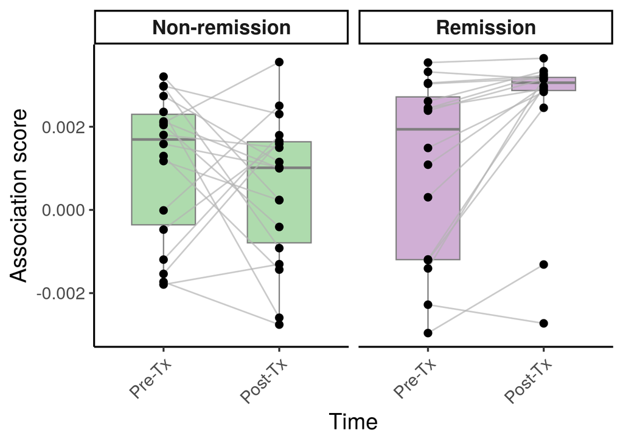

```r
library(dplyr); library(tidyr); library(ggplot2)
forAnalysis <- data.frame(obj2@metadata, obj2@nam_pcs, obj2@umap)
colnames(forAnalysis)[grep("PC", colnames(forAnalysis))] <- paste0("NAM_", colnames(forAnalysis)[grep("PC", colnames(forAnalysis))])
forAnalysis$Treatment <- factor(forAnalysis$Treatment, levels = c("Pre","Post"))

paired_dat <- forAnalysis %>%
  dplyr::group_by(Patient, Treatment, Remission_status) %>%
  dplyr::summarise(NAM_PC1 = median(NAM_PC1, na.rm = TRUE), .groups = "drop") %>%
  tidyr::pivot_wider(names_from = Treatment, values_from = NAM_PC1) %>%
  tidyr::drop_na(Pre, Post) %>%
  tidyr::pivot_longer(c(Pre, Post), names_to = "Treatment", values_to = "NAM_PC1") %>%
  mutate(Treatment = factor(Treatment, levels = c("Pre","Post")))

paired_dat$Treatment <- factor(paired_dat$Treatment,
                               levels = c("Pre","Post"),
                               labels = c("Pre-Tx","Post-Tx"))

paired_dat$Remission_status <- gsub("Non_Remission", "Non-remission", paired_dat$Remission_status)


p4 <- ggplot(paired_dat, aes(x = Treatment, y = NAM_PC1)) +
  # colored boxplots behind
  geom_boxplot(aes(group = Treatment, fill = Remission_status),
               width = 0.55, outlier.shape = NA,
               color = "grey50", alpha = 0.45) +
  # grey connecting lines
  geom_line(aes(group = Patient), color = "grey70", linewidth = 0.6, alpha = 0.7) +
  # black points
  geom_point(color = "black", size = 2.6) +
  facet_wrap(~ Remission_status, nrow = 1) +
  scale_fill_manual(values = c("Non-remission" = "#4DAF4A", "Remission" = "#984EA3")) +
  labs(x = "Time", y = "Association score") +
  theme_classic(base_size = 16) +
  theme(
    strip.text  = element_text(size = 16, face = "bold"),
    axis.title  = element_text(size = 18),
    axis.text   = element_text(size = 14),
    axis.text.x = element_text(angle = 45, hjust = 1),
    legend.position = "none"
  )
p4
```

## UMAP Colored By Association Score

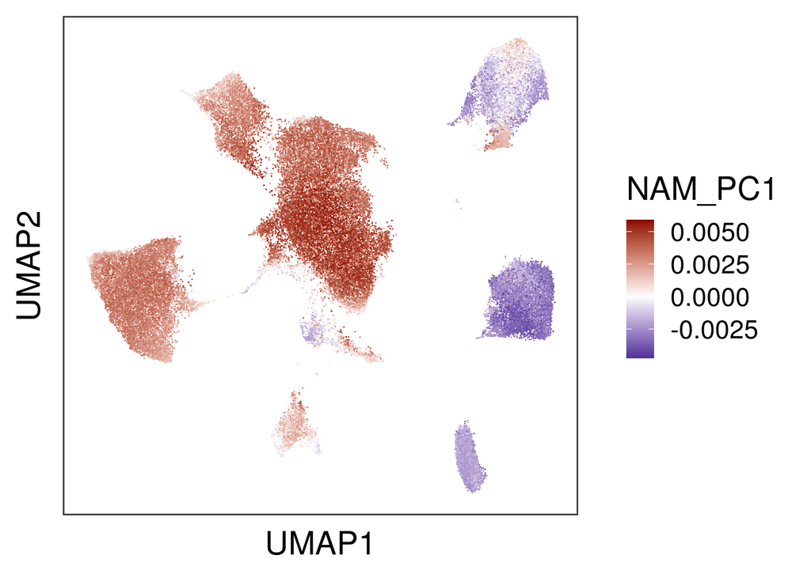

```r
#### UMAP with PC
fig_umap2 <- ggplot() +
 geom_point(
    data = forAnalysis[sample(nrow(forAnalysis)), ],
    mapping = aes(x = UMAP1, y = UMAP2, fill = NAM_PC1),
    size = 0.5, stroke = 0.01, shape = 21
  ) +
  scale_fill_gradient2(
    low = "navy",        # Low values (dark blue)
    mid = "white",       # Middle values (white)
    high = "darkred",    # High values (dark red)
    midpoint = 0         # Set the midpoint to 0
  ) +
  labs(
    x = "UMAP1",
    y = "UMAP2",
    #title = "IBD Fibroblasts: Association Score",
    #subtitle = "N cells = 100, N samples = 30"
  ) +
  theme_bw(base_size = 20) +
  theme(
    legend.position = "right",
    axis.text = element_blank(),
    axis.ticks = element_blank(),
    panel.grid = element_blank(),
    plot.title = element_text(color = "black", size = 20),
    plot.subtitle = element_text(color = "black", size = 10)
  )

fig_umap2
```

# Cell Types

## UMAP colored by cell type

The cell types are defined from the paper. What does this look like on the UMAP?

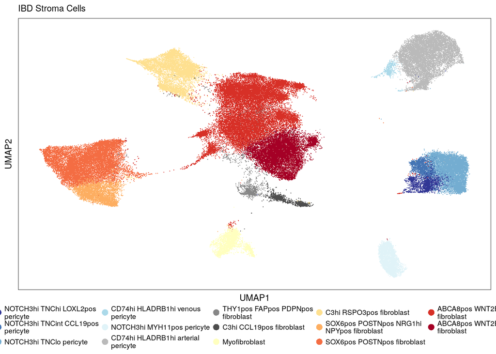

```r
#### PLOTS #####
### UMAP by cell type from paper
library(dplyr)
cluster_center <- data.frame(forAnalysis) %>%
  group_by(final_analysis) %>%
  summarise(
    median_UMAP1 = median(UMAP1, na.rm = TRUE),
    median_UMAP2 = median(UMAP2, na.rm = TRUE)
  )
cluster_center <- as.data.frame(cluster_center)

library(RColorBrewer)

# your inputs
want <- c("NOTCH3hi TNClo pericyte",
          "NOTCH3hi TNCint CCL19pos pericyte",
          "NOTCH3hi TNChi LOXL2pos pericyte",
          "C3hi CCL19pos fibroblast")

library(stringr)
library(RColorBrewer)
cols_11 <- brewer.pal(n=11, "RdYlBu")
cols_extra3 <- brewer.pal(n=9, "RdGy")[c(7:9)]
cols_order_want <- c(cols_11[c(11, 10, 9, 8, 7)], cols_extra3, cols_11[c(6, 5, 4, 3, 2, 1)])


library(forcats)
forAnalysis <- forAnalysis %>%
  filter(!is.na(final_analysis), !is.na(NAM_PC1)) %>%
  mutate(cell_type = fct_reorder(final_analysis, NAM_PC1, .fun = median, na.rm = TRUE))

# ensure the factor levels in your plotting data match the palette order
#forAnalysis2$final_analysis <- factor(forAnalysis2$final_analysis, levels = names(cols_in_level_order))
library(stringr)
lab_wrap <- str_wrap(levels(forAnalysis$cell_type), width = 28)  # tweak width

cell_type <- levels(forAnalysis$cell_type)
g2 <- ggplot() +
  geom_point(
    data = forAnalysis[sample(nrow(forAnalysis)), ],
    aes(x = UMAP1, y = UMAP2, fill = cell_type),
    size = 0.4, stroke = 0.0001, shape = 21
  ) +
  scale_fill_manual(
    values = cols_order_want,
    breaks = cell_type,
    labels = lab_wrap,                    # wrapped labels
    drop = FALSE,
    name = "Cell Type"
  ) +
  guides(fill = guide_legend(
    override.aes = list(size = 3),
    keyheight = unit(2.5, "mm"),
    keywidth  = unit(2.5, "mm")
  )) +
  labs(x = "UMAP1", y = "UMAP2", title = "IBD Stroma Cells") +
  theme_bw(base_size = 9) +
  theme(
    legend.position = "bottom",
    axis.text = element_blank(),
    axis.ticks = element_blank(),
    panel.grid = element_blank(),
    plot.title = element_text(color = "black", size = 9),
    plot.subtitle = element_text(color = "black", size = 7),
    legend.box = "horizontal",
    legend.title = element_text(size = 4),
    legend.box.spacing = unit(2, "pt"),   # space between plot and legend
    legend.margin = margin(0, 0, 0, 0),   # margin around the whole legend
    legend.key.height = unit(4, "pt"),    # key height (colorbar thickness area)
    legend.key.width  = unit(60, "pt"),   # key length
    plot.margin = margin(5, 5, 5, 5)      # trim outer plot margins if needed
  )
g2
```

## Association score cell type boxplot

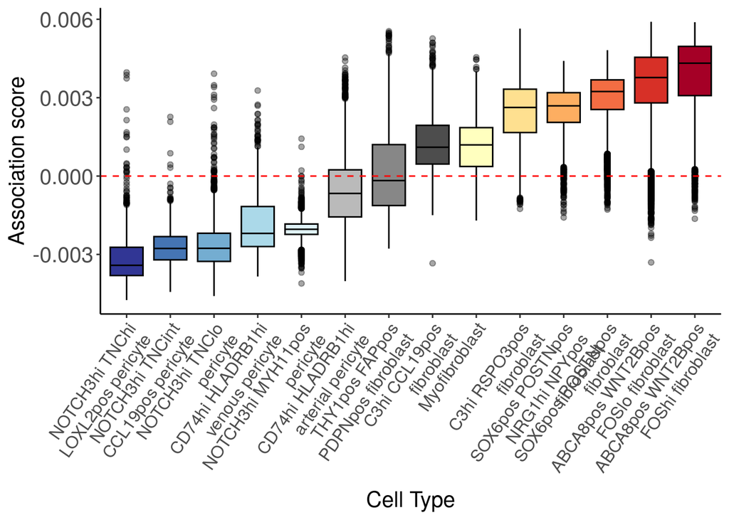

```r
#### Boxplot with Cell Type.
library(forcats)
library(ggplot2)

# order levels of final_analysis from lowest → highest median NAM_PC1
forAnalysis <- forAnalysis |>
  mutate(final_analysis = fct_reorder(final_analysis, NAM_PC1,
                                      .fun = ~median(., na.rm = TRUE),
                                      .desc = FALSE))

#levels(forAnalysis2$final_analysis)
## get colors for cell types updated to RedBlue from RColorBrewer;
library(RColorBrewer)
cols_11 <- brewer.pal(n=11, "RdYlBu")
cols_extra3 <- brewer.pal(n=9, "RdGy")[c(7:9)]
cols_order_want <- c(cols_11[c(11, 10, 9, 8, 7)], cols_extra3, cols_11[c(6, 5, 4, 3, 2, 1)])

library(stringr)

p2 <- ggplot(forAnalysis,
             aes(x = final_analysis, y = NAM_PC1, fill = final_analysis)) +
  geom_boxplot(
    position = position_dodge(width = 0.8),
    outlier.alpha = 0.35,
    color = "black",      # keep black outlines/median
    fatten = 1
  ) +
  geom_hline(yintercept = 0, linetype = "dashed", color = "red") +
  labs(x = "Cell Type", y = "Association score") +
  scale_fill_manual(values = cols_order_want, drop = FALSE) +
  guides(fill = "none") +                    # remove legend; rely on x-axis names
  scale_x_discrete(
    labels = function(x) str_wrap(x, width = 20)  # wrap long names
    # or: guide = guide_axis(angle = 55, n.dodge = 2)
  ) +
  theme_classic() +
  theme(
    axis.text    = element_text(size = 15),                        # tick labels (both axes)
    axis.text.x  = element_text(angle = 55, hjust = 1, vjust = 1, size = 12),
    axis.title.x = element_text(size = 15),                        # x-axis title
    axis.title.y = element_text(size = 15),                        # y-axis title
    axis.ticks.x = element_line()
  )
p2
```

## Association score prediction of cell types

First let’s calculate the ROCs for each of the cell types.

```r
#### Use Prediction for PCs ####
library(Matrix)
library(lme4)
library(pROC)
library(ggplot2)
library(dplyr)


##### Function to Get ROC Info #####
getROCobj <- function(cellType_want, data, seed){
  #set up dataset
  tmp <- data
  tmp$cellType <- ifelse(tmp$cell_type==cellType_want, 1, 0)

  #perform model
  mod <- glm(cellType ~ NAM_PC1, data=tmp, family=binomial)
  pred_probs <- stats::predict(mod, type="response")

  #get ROC
  roc_obj <- roc(tmp$cellType, pred_probs)
  auc_value <- pROC::auc(roc_obj)

  ci_auc <- pROC::ci.auc(roc_obj, conf.level = 0.95)  # DeLong by default
  set.seed(seed)
  ci_band <- pROC::ci.se(
    roc_obj,
    specificities = seq(0, 1, by = 0.01),
    boot.n = 100,
    boot.stratified = TRUE,
    progress = "none"
  )

  # Save output we need
  want <- list(roc_obj, auc_value, ci_auc, ci_band)
  names(want) <- c("roc_obj", "auc", "ci.auc", "ci.se")
  return(want)
}


#### Get the ROC Info for Each Cell Type ####
forAnalysis$cell_type <- forAnalysis$final_analysis
cellTypes <- unique(forAnalysis$final_analysis)

ibd_roc_c3hi_ccl19plus <- getROCobj(cellType_want = "C3hi CCL19pos fibroblast", forAnalysis, 2020)
ibd_roc_thy1pos <- getROCobj(cellType_want = "THY1pos FAPpos PDPNpos fibroblast", forAnalysis, 2020)
ibd_roc_notch3hi_tnchi <- getROCobj(cellType_want = "NOTCH3hi TNChi LOXL2pos pericyte", forAnalysis, 2020)
ibd_roc_notch3hi_tnclo <- getROCobj(cellType_want = "NOTCH3hi TNClo pericyte", forAnalysis, 2020)
ibd_roc_CD74hi <- getROCobj(cellType_want = "CD74hi HLADRB1hi venous pericyte", forAnalysis, 2020)
ibd_roc_notch3other <- getROCobj(cellType_want = "NOTCH3hi TNCint CCL19pos pericyte", forAnalysis, 2020)

ibd_roc_ABCA8_FOShi <- getROCobj(cellType_want = "ABCA8pos WNT2Bpos FOShi fibroblast", forAnalysis, 2020)
ibd_roc_ABCA8_FOSlo <- getROCobj(cellType_want = "ABCA8pos WNT2Bpos FOSlo fibroblast", forAnalysis, 2020)
ibd_roc_c3hi_rspo3pos <- getROCobj(cellType_want = "C3hi RSPO3pos fibroblast", forAnalysis, 2020)
ibd_roc_CD74hi_arterial <- getROCobj(cellType_want = "CD74hi HLADRB1hi arterial pericyte", forAnalysis, 2020)
ibd_roc_Myofibroblast <- getROCobj(cellType_want = "Myofibroblast", forAnalysis, 2020)
ibd_roc_notch3hi_myh11 <- getROCobj(cellType_want = "NOTCH3hi MYH11pos pericyte", forAnalysis, 2020)
ibd_roc_sox6_npy <- getROCobj(cellType_want = "SOX6pos POSTNpos NRG1hi NPYpos fibroblast", forAnalysis, 2020)
ibd_roc_sox6_postn <- getROCobj(cellType_want = "SOX6pos POSTNpos fibroblast", forAnalysis, 2020)

#### Plot the ROCs Together###
library(RColorBrewer)
# Put your results into a named list (order as you like)
rocs <- list(
  "C3hi CCL19+ fibroblast" = ibd_roc_c3hi_ccl19plus,
  "Thy1+ FAP+ PDPN+ fibroblast" = ibd_roc_thy1pos,
  "NOTCH3hi TNChi LOXL2pos pericyte" = ibd_roc_notch3hi_tnchi,
  "NOTCH3hi TNClo pericyte" = ibd_roc_notch3hi_tnclo,
  "CD74hi HLADRB1hi venous pericyte" = ibd_roc_CD74hi,
  "NOTCH3hi TNCint CCL19pos pericyte" = ibd_roc_notch3other,

  "ABCA8pos WNT2Bpos FOShi fibroblast" = ibd_roc_ABCA8_FOShi,
  "ABCA8pos WNT2Bpos FOSlo fibroblast" = ibd_roc_ABCA8_FOSlo,
  "C3hi RSPO3pos fibroblast" = ibd_roc_c3hi_rspo3pos,
  "CD74hi HLADRB1hi arterial pericyte" = ibd_roc_CD74hi_arterial,
  "Myofibroblast" = ibd_roc_Myofibroblast,
  "NOTCH3hi MYH11pos pericyte" = ibd_roc_notch3hi_myh11,
  "SOX6pos POSTNpos NRG1hi NPYpos fibroblast" = ibd_roc_sox6_npy,
  "SOX6pos POSTNpos fibroblast" = ibd_roc_sox6_postn
)

saveRDS(rocs, file="/pl/active/fanzhanglab/lvanderlinden/publicDatasets/IBD_Thomas2024/data/longMod_v1/NAMPC1_cellType_ROCS.rds")
```

Plot just the to performing ones (NOTCH3) and one that is somewhat in the middle.

[figure not shown]

```r
rocs_all <- readRDS(file="/pl/active/fanzhanglab/lvanderlinden/publicDatasets/IBD_Thomas2024/data/longMod_v1/NAMPC1_cellType_ROCS.rds")
names(rocs_all) <- gsub("+", "pos", names(rocs_all), fixed=TRUE)
want <- c("NOTCH3hi TNClo pericyte",
          "NOTCH3hi TNCint CCL19pos pericyte",
          "NOTCH3hi TNChi LOXL2pos pericyte",
          "C3hi CCL19pos fibroblast")
rocs <- rocs_all[which(names(rocs_all) %in% want)]

# Colors (use the colors that you defined above). Use lighter alpha for CI bands.
cols <- cols_order_want[c(8, 1, 3, 2)]
fills <- vapply(cols, \(z) adjustcolor(z, alpha.f = 0.25), character(1))

pdf(
  file = "/pl/active/fanzhanglab/lvanderlinden/publicDatasets/IBD_Thomas2024/data/longMod_v1/NAMPC1_ROC_fibroblasts_fig2_select4CT_newColors.pdf",
  width = 9, height = 7.6
)

## -------- Layout: plot (top) + custom legend (bottom) --------
layout(matrix(c(1, 2), nrow = 2, byrow = TRUE), heights = c(6.0, 1.6))
## -------- Top panel (ROC) --------
par(mar = c(5.2, 5.2, 3.8, 2.2), cex = 1.15, cex.axis = 1.1, cex.lab = 1.3)

# remove axis padding to kill the white space
op <- par(xaxs = "i", yaxs = "i"); on.exit(par(op), add = TRUE)

first <- rocs[[1]]
plot(
  first$roc_obj,
  main = "Association Score Predicting Cell Type",
  col = NA,
  legacy.axes = TRUE,      # keep classic "1 - Specificity" axis
  xlim = c(0.5, 0),          # <-- 0→1 left-to-right for legacy axes
  ylim = c(0, 1),          # clamp y as well
  lwd  = 5,                # thicker baseline
  cex.main = 2.55
)

# CI polygons (UNCHANGED from your working version)
i <- 0
for (nm in names(rocs)) {
  i <- i + 1
  ci_mat <- as.matrix(rocs[[nm]]$ci.se)
  sp      <- as.numeric(rownames(ci_mat))
  polygon(
    c(sp, rev(sp)),
    c(ci_mat[, 1], rev(ci_mat[, 3])),
    col = fills[i], border = NA
  )
}

# ROC lines (thicker)
i <- 0
for (nm in names(rocs)) {
  i <- i + 1
  plot(rocs[[nm]]$roc_obj, add = TRUE, lwd = 5, col = cols[i])
}

## -------- Bottom panel: custom 2-column legend --------
par(mar = c(0.2, 0.4, 0.2, 0.4))
plot.new()
par(xpd = NA); par(usr = c(0, 1, 0, 1))

make_entry <- function(nm, obj) {
  auc_val <- as.numeric(pROC::auc(obj$roc_obj))
  ci_val  <- try(pROC::ci.auc(obj$roc_obj), silent = TRUE)
  line1 <- sprintf("%s:", nm)
  line2 <- if (inherits(ci_val, "try-error")) {
    sprintf("AUC = %.3f", auc_val)
  } else {
    sprintf("AUC = %.3f (95%% CI %.3f, %.3f)", auc_val, ci_val[1], ci_val[3])
  }
  list(line1 = line1, line2 = line2)
}
entries <- lapply(names(rocs), function(nm) make_entry(nm, rocs[[nm]]))

n <- length(entries); half <- ceiling(n/2)
left_idx  <- seq_len(half)
right_idx <- if (n > half) (half + 1):n else integer(0)

cex_leg <- 1.05
lh    <- strheight("X", cex = cex_leg)
gap   <- 3.1 * lh
delta <- 1.15 * lh
y_top <- 0.93

# Column anchors
col1 <- list(x_seg0 = 0.03, x_seg1 = 0.11, x_text = 0.13)
col2 <- list(x_seg0 = 0.53, x_seg1 = 0.61, x_text = 0.63)

# --- Keep segments() inside this function so colspec/idx are in scope ---
draw_col <- function(idxs, colspec, cols_palette) {
  for (k in seq_along(idxs)) {
    idx <- idxs[k]; ent <- entries[[idx]]
    y <- y_top - (k - 1) * gap

    # thicker swatch to match ROC lines
    segments(
      colspec$x_seg0, y - 0.5 * lh,
      colspec$x_seg1, y - 0.5 * lh,
      lwd = 5,                          # thickness here
      col = cols_palette[idx]
    )

    text(colspec$x_text, y,         ent$line1, adj = c(0, 0.5), cex = cex_leg)
    text(colspec$x_text, y - delta, ent$line2, adj = c(0, 0.5), cex = cex_leg)
  }
}

draw_col(left_idx,  col1, cols)
if (length(right_idx)) draw_col(right_idx, col2, cols)

layout(1); dev.off()
```